# Topic 7: Tree Based Models

MS in Statistics for Data Science

UC3M, 2025-2026

# 1 Introduction

In this notebook mirrors we will practice with the tree based models seen in topic 7:

1. Single decision trees (with pruning)
2. Bagging
3. Random forests
4. Boosting (GBM, XGBoost)

We will first show some basic results with `iris` (classification) and `mtcars` (regression), and then we will study bigger datasets: `Heart` and `Boston`

The next chunks load packages, set reproducibility controls, and define only the essential metric helpers used throughout.

```r
library(ISLR2)
library(tree)
library(rpart)
library(randomForest)
library(gbm)
library(xgboost)
library(caret)
library(dplyr)
library(ggplot2)
library(tidyr)
library(purrr)
library(tibble)
library(forcats)
```

```r
# Set a seed to be used whenever we have a random process
my_seed <- 42

# Set number of trees values for ensembles and Cross Validation folds
ntree_fast <- 250
ntree_main <- 350
cv_folds <- 3
```

```r
# Custom metric functions
class_metrics <- function(truth, pred, positive = "Yes") {
  truth <- factor(truth, levels = c("No", "Yes"))
  pred <- factor(pred, levels = c("No", "Yes"))

  tp <- sum(truth == positive & pred == positive)
  tn <- sum(truth != positive & pred != positive)
  fp <- sum(truth != positive & pred == positive)
  fn <- sum(truth == positive & pred != positive)

  acc <- (tp + tn) / length(truth)
  sens <- ifelse(tp + fn > 0, tp / (tp + fn), NA_real_)
  spec <- ifelse(tn + fp > 0, tn / (tn + fp), NA_real_)

  tibble(
    Accuracy = acc,
    Sensitivity = sens,
    Specificity = spec
  )
}

reg_metrics <- function(truth, pred) {
  rmse <- sqrt(mean((truth - pred)^2))
  mae <- mean(abs(truth - pred))
  rsq <- 1 - sum((truth - pred)^2) / sum((truth - mean(truth))^2)

  tibble(
    RMSE = rmse,
    MAE = mae,
    R2 = rsq
  )
}
```

# 2 Classification Tree (`iris`)

We use the classic Iris dataset (3 flower species, 4 numeric predictors) to learn the basic tree workflow. We start by creating a stratified train/test split with `caret`, and in this first example we focus on `Petal.Length` and `Petal.Width` so we can visualise the tree partition directly in 2D.

```r
data(iris)

set.seed(123)
iris_idx <- createDataPartition(iris$Species, p = 0.7, list = FALSE)
iris_train <- iris[iris_idx, ]
iris_test  <- iris[-iris_idx, ]

cat("Train:", nrow(iris_train), "| Test:", nrow(iris_test), "\n")
```

```
## Train: 105 | Test: 45
```

The main function is `tree()` from the `tree` package. Some of its arguments are:

- `formula`
- `data`
- `control = tree.control(...)` which governs how large the tree grows with the following parameters:
  - `nobs` (number of observations, required)
  - `mindev` (minimum deviance improvement required to attempt a split; smaller values grow bigger trees, default `0.01`)
  - `minsize` (minimum observations per terminal node, default `10`).

```r
iris_tree <- tree(
  Species ~ Petal.Length + Petal.Width,
  data    = iris_train,
  control = tree.control(
    nobs    = nrow(iris_train),
    mindev  = 0.01,   # lower = bigger tree
    minsize = 5       # min obs per leaf
  )
)

summary(iris_tree)
```

```
##
## Classification tree:
## tree(formula = Species ~ Petal.Length + Petal.Width, data = iris_train,
##     control = tree.control(nobs = nrow(iris_train), mindev = 0.01,
##         minsize = 5))
## Number of terminal nodes:  5
## Residual mean deviance:  0.03819 = 3.819 / 100
## Misclassification error rate: 0.009524 = 1 / 105
```

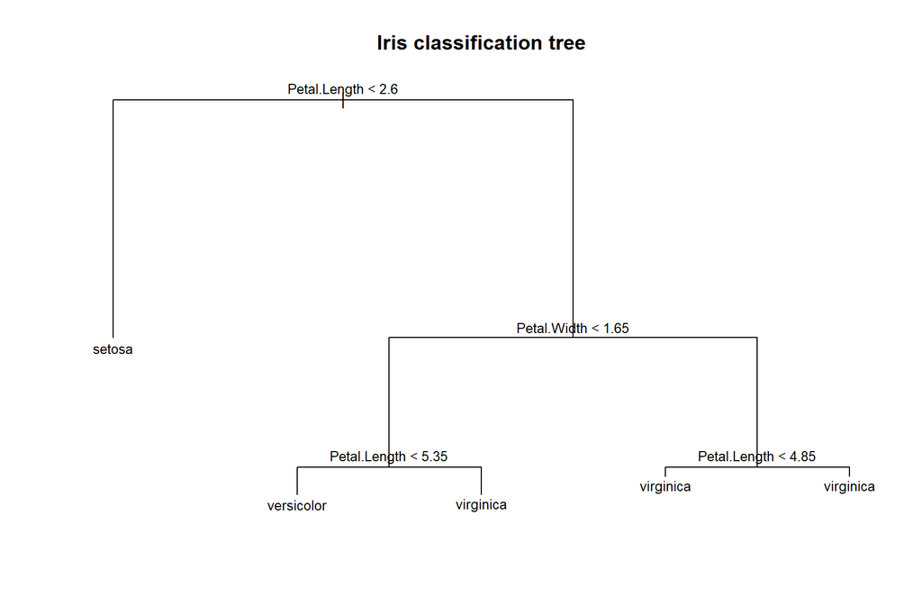

```r
plot(iris_tree)
text(iris_tree, pretty = 0, cex = 0.8)
title("Iris classification tree")
```

Each internal node shows the splitting variable and threshold; each leaf shows the predicted class.

Because we used two predictors, we can plot the feature-space partition induced by the tree.

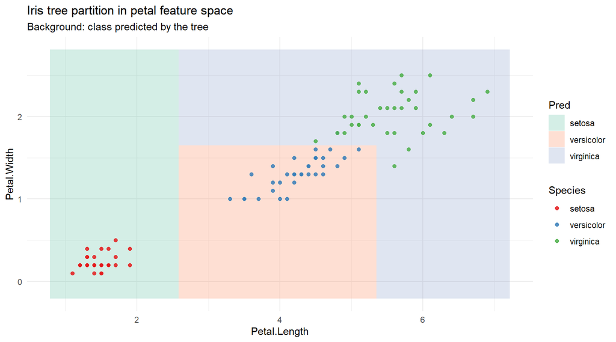

```r
iris_grid <- expand.grid(
  Petal.Length = seq(min(iris_train$Petal.Length) - 0.3,
                     max(iris_train$Petal.Length) + 0.3,
                     length.out = 200),
  Petal.Width  = seq(min(iris_train$Petal.Width) - 0.3,
                     max(iris_train$Petal.Width) + 0.3,
                     length.out = 200)
)

iris_grid$Pred <- predict(iris_tree, newdata = iris_grid, type = "class")

ggplot() +
  geom_tile(
    data = iris_grid,
    aes(x = Petal.Length, y = Petal.Width, fill = Pred),
    alpha = 0.28
  ) +
  geom_point(
    data = iris_train,
    aes(x = Petal.Length, y = Petal.Width, color = Species),
    size = 1.6,
    alpha = 0.85
  ) +
  labs(
    title = "Iris tree partition in petal feature space",
    subtitle = "Background: class predicted by the tree",
    x = "Petal.Length",
    y = "Petal.Width"
  ) +
  scale_fill_brewer(palette = "Set2") +
  scale_color_brewer(palette = "Set1") +
  theme_minimal()
```

To evaluate on the test set we use `predict()` with `type = "class"`, which returns the predicted class directly instead of the default probability matrix.

```r
iris_tree_pred <- predict(iris_tree, newdata = iris_test, type = "class")
confusionMatrix(iris_tree_pred, iris_test$Species)
```

```
## Confusion Matrix and Statistics
##
##             Reference
## Prediction   setosa versicolor virginica
##   setosa         15          0         0
##   versicolor      0         14         2
##   virginica       0          1        13
##
## Overall Statistics
##
##                Accuracy : 0.9333
##                  95% CI : (0.8173, 0.986)
##     No Information Rate : 0.3333
##     P-Value [Acc > NIR] : < 2.2e-16
##
##                   Kappa : 0.9
##
##  Mcnemar's Test P-Value : NA
##
## Statistics by Class:
##
##                      Class: setosa Class: versicolor Class: virginica
## Sensitivity                 1.0000            0.9333           0.8667
## Specificity                 1.0000            0.9333           0.9667
## Pos Pred Value              1.0000            0.8750           0.9286
## Neg Pred Value              1.0000            0.9655           0.9355
## Prevalence                  0.3333            0.3333           0.3333
## Detection Rate              0.3333            0.3111           0.2889
## Detection Prevalence        0.3333            0.3556           0.3111
## Balanced Accuracy           1.0000            0.9333           0.9167
```

A large tree may overfit. Pruning addresses this by first growing a full tree and then using cross-validation to select the number of leaves that minimises CV error. The workflow is:

1. Grow a large tree with `mindev = 0`
2. Run `cv.tree()` with `FUN = prune.misclass` to use misclassification error instead of deviance
3. Pick the size with the lowest CV error
4. Call `prune.misclass(big_tree, best = chosen_size)`.

The `cv.tree` object contains `$size` (number of terminal nodes), `$dev` (CV error), and `$k` (the regularisation penalty alpha).

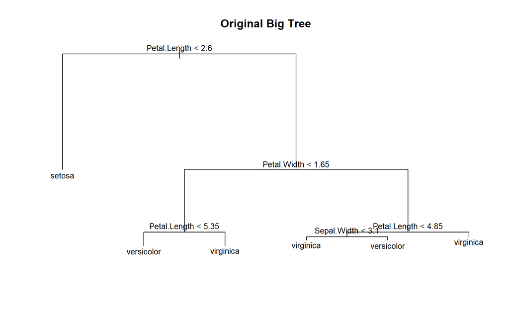

```r
iris_big <- tree(
  Species ~ .,
  data    = iris_train,
  control = tree.control(nobs = nrow(iris_train), mindev = 0, minsize = 2)
)

plot(iris_big)
text(iris_big, pretty = 0, cex = 0.85)
title(paste("Original Big Tree"))
```

```r
set.seed(3302)
iris_cv <- cv.tree(iris_big, FUN = prune.misclass)

# Show the results
iris_cv
```

```
## $size
## [1] 6 4 3 2 1
##
## $dev
## [1]  6  6  6 84 84
##
## $k
## [1] -Inf  0.5  2.0 32.0 35.0
##
## $method
## [1] "misclass"
##
## attr(,"class")
## [1] "prune"         "tree.sequence"
```

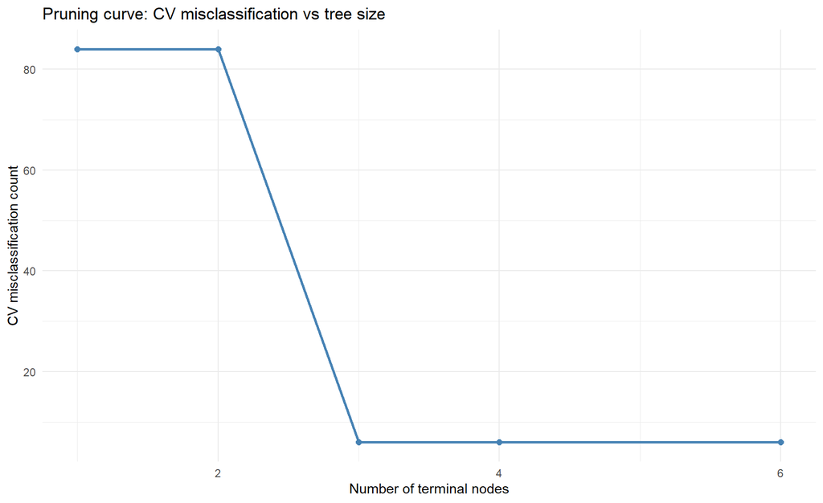

```r
# Create a plot
tibble(size = iris_cv$size, cv_error = iris_cv$dev) %>%
  ggplot(aes(x = size, y = cv_error)) +
  geom_line(color = "steelblue", linewidth = 1) +
  geom_point(color = "steelblue", size = 2) +
  labs(
    title = "Pruning curve: CV misclassification vs tree size",
    x = "Number of terminal nodes",
    y = "CV misclassification count"
  ) +
  theme_minimal()
```

```r
# Selecting the tree size with minimum CV error
best_size <- iris_cv$size[which.min(iris_cv$dev)]
cat("Best tree size (terminal nodes):", best_size, "\n")
```

```
## Best tree size (terminal nodes): 6
```

```r
# But this is the same size as the big one!
# In this case there are several values with minimum CV error
# We should then choose the smallest size one given that they have the same CV error
# The following code does precisely that
min_dev <- min(iris_cv$dev, na.rm = TRUE)
best_size <- min(iris_cv$size[iris_cv$dev == min_dev], na.rm = TRUE)
cat("Best tree size (terminal nodes):", best_size, "\n")
```

```
## Best tree size (terminal nodes): 3
```

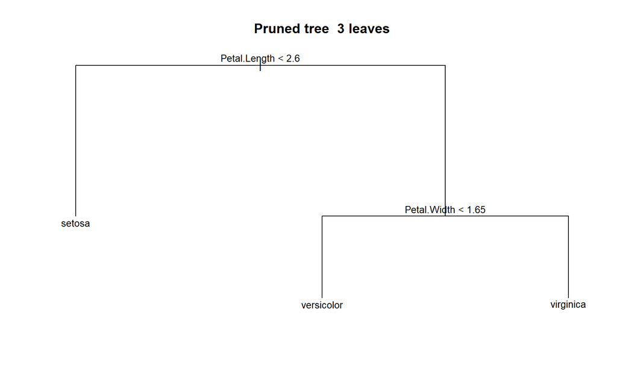

```r
iris_pruned <- prune.misclass(iris_big, best = best_size)

plot(iris_pruned)
text(iris_pruned, pretty = 0, cex = 0.85)
title(paste("Pruned tree ", best_size, "leaves"))
```

```r
iris_pruned_pred <- predict(iris_pruned, newdata = iris_test, type = "class")
confusionMatrix(iris_pruned_pred, iris_test$Species)
```

```
## Confusion Matrix and Statistics
##
##             Reference
## Prediction   setosa versicolor virginica
##   setosa         15          0         0
##   versicolor      0         14         2
##   virginica       0          1        13
##
## Overall Statistics
##
##                Accuracy : 0.9333
##                  95% CI : (0.8173, 0.986)
##     No Information Rate : 0.3333
##     P-Value [Acc > NIR] : < 2.2e-16
##
##                   Kappa : 0.9
##
##  Mcnemar's Test P-Value : NA
##
## Statistics by Class:
##
##                      Class: setosa Class: versicolor Class: virginica
## Sensitivity                 1.0000            0.9333           0.8667
## Specificity                 1.0000            0.9333           0.9667
## Pos Pred Value              1.0000            0.8750           0.9286
## Neg Pred Value              1.0000            0.9655           0.9355
## Prevalence                  0.3333            0.3333           0.3333
## Detection Rate              0.3333            0.3111           0.2889
## Detection Prevalence        0.3333            0.3556           0.3111
## Balanced Accuracy           1.0000            0.9333           0.9167
```

You can see how the accuracy is the same as the unprunned tree, but its smaller in size and therefore more interpretable.

# 3 Bagging and Random Forest (`iris`)

To use bagging, we saw that its indeed an special case of a random forest where `m = p`. Therefore both methods come from the `randomForest` package and share the same interface, where the key argument is `mtry`, the number of candidate predictors randomly sampled at each split. Setting `mtry = p` (all predictors) gives **bagging**, while `mtry = floor(sqrt(p))` (the default for classification) gives a **random forest**. The argument `ntree` controls the total number of trees (default 500; more trees are rarely harmful as it will not overfit due to the averaging, just slower), and `importance = TRUE` enables variable importance computation.

Starting with bagging we will fit 500 trees, each seeing all 4 predictors at every split (`m=p`).

```r
p <- ncol(iris_train) - 1   # number of predictors

set.seed(3303)
iris_bag <- randomForest(
  Species   ~ .,
  data       = iris_train,
  mtry       = p,           # bagging: use ALL predictors at each split
  ntree      = 500,
  importance = TRUE
)

iris_bag   # prints OOB confusion matrix and error
```

```
##
## Call:
##  randomForest(formula = Species ~ ., data = iris_train, mtry = p,      ntree = 500, importance = TRUE)
##                Type of random forest: classification
##                      Number of trees: 500
## No. of variables tried at each split: 4
##
##         OOB estimate of  error rate: 4.76%
## Confusion matrix:
##            setosa versicolor virginica class.error
## setosa         35          0         0  0.00000000
## versicolor      0         33         2  0.05714286
## virginica       0          3        32  0.08571429
```

Remember that the **OOB (out-of-bag) error** printed by the model is a built-in estimate of test error at no extra cost: each tree only uses ~63 % of training cases, so the remaining ~37 % act as a held-out set for that tree. Therefore we dont have the need to explicitly use cross-validation

```r
iris_bag_pred <- predict(iris_bag, newdata = iris_test, type = "class")
confusionMatrix(iris_bag_pred, iris_test$Species)
```

```
## Confusion Matrix and Statistics
##
##             Reference
## Prediction   setosa versicolor virginica
##   setosa         15          0         0
##   versicolor      0         14         2
##   virginica       0          1        13
##
## Overall Statistics
##
##                Accuracy : 0.9333
##                  95% CI : (0.8173, 0.986)
##     No Information Rate : 0.3333
##     P-Value [Acc > NIR] : < 2.2e-16
##
##                   Kappa : 0.9
##
##  Mcnemar's Test P-Value : NA
##
## Statistics by Class:
##
##                      Class: setosa Class: versicolor Class: virginica
## Sensitivity                 1.0000            0.9333           0.8667
## Specificity                 1.0000            0.9333           0.9667
## Pos Pred Value              1.0000            0.8750           0.9286
## Neg Pred Value              1.0000            0.9655           0.9355
## Prevalence                  0.3333            0.3333           0.3333
## Detection Rate              0.3333            0.3111           0.2889
## Detection Prevalence        0.3333            0.3556           0.3111
## Balanced Accuracy           1.0000            0.9333           0.9167
```

Now we fit the random forest, reducing `mtry` to `floor(sqrt(p))` so that only a random subset of features is considered at each split. This decorrelates the trees and typically improves the ensemble.

```r
set.seed(3304)
iris_rf <- randomForest(
  Species   ~ .,
  data      = iris_train,
  mtry      = floor(sqrt(p)),  # default: sqrt(p) for classification
  ntree     = 500,
  importance = TRUE
)

iris_rf
```

```
##
## Call:
##  randomForest(formula = Species ~ ., data = iris_train, mtry = floor(sqrt(p)),      ntree = 500, importance = TRUE)
##                Type of random forest: classification
##                      Number of trees: 500
## No. of variables tried at each split: 2
##
##         OOB estimate of  error rate: 4.76%
## Confusion matrix:
##            setosa versicolor virginica class.error
## setosa         35          0         0  0.00000000
## versicolor      0         33         2  0.05714286
## virginica       0          3        32  0.08571429
```

```r
iris_rf_pred <- predict(iris_rf, newdata = iris_test, type = "class")
confusionMatrix(iris_rf_pred, iris_test$Species)
```

```
## Confusion Matrix and Statistics
##
##             Reference
## Prediction   setosa versicolor virginica
##   setosa         15          0         0
##   versicolor      0         14         2
##   virginica       0          1        13
##
## Overall Statistics
##
##                Accuracy : 0.9333
##                  95% CI : (0.8173, 0.986)
##     No Information Rate : 0.3333
##     P-Value [Acc > NIR] : < 2.2e-16
##
##                   Kappa : 0.9
##
##  Mcnemar's Test P-Value : NA
##
## Statistics by Class:
##
##                      Class: setosa Class: versicolor Class: virginica
## Sensitivity                 1.0000            0.9333           0.8667
## Specificity                 1.0000            0.9333           0.9667
## Pos Pred Value              1.0000            0.8750           0.9286
## Neg Pred Value              1.0000            0.9655           0.9355
## Prevalence                  0.3333            0.3333           0.3333
## Detection Rate              0.3333            0.3111           0.2889
## Detection Prevalence        0.3333            0.3556           0.3111
## Balanced Accuracy           1.0000            0.9333           0.9167
```

In this case, as `iris` is a very simple dataset we get the same accuracy with all the models, but we will later see how this changes in more complex datasets.

With `importance = TRUE` we can inspect which variables mattered most. `importance()` returns two types of scores: **MeanDecreaseAccuracy** (`type = 1`) measures how much accuracy drops when each variable is permuted at random (higher = more important), and **MeanDecreaseGini** (`type = 2`) sums the total node impurity decrease from splits on that variable across all trees. `varImpPlot()` visualises both at once.

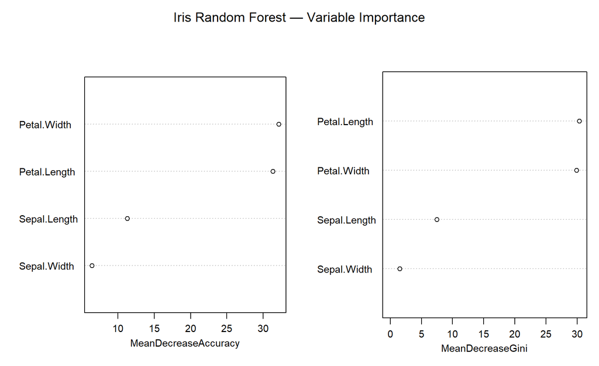

```r
varImpPlot(iris_rf, main = "Iris Random Forest — Variable Importance", cex = 0.9)
```

# 4 Regression Tree (mtcars)

We have been using tree-based models with classification examples but trees also work for **continuous targets**. The syntax is identical: `predict()` then returns a numeric vector and the tree minimises residual sum of squares (RSS) at each split instead of impurity. We use `mtcars` to predict fuel efficiency (`mpg`) from the other car features.

```r
data(mtcars)
set.seed(456)
mt_idx   <- createDataPartition(mtcars$mpg, p = 0.75, list = FALSE)
mt_train <- mtcars[mt_idx, ]
mt_test  <- mtcars[-mt_idx, ]
```

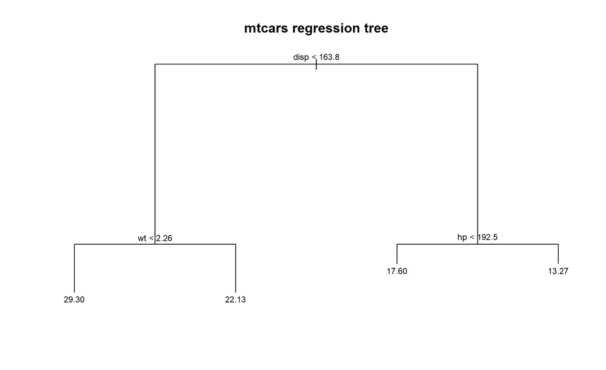

```r
mt_tree <- tree(mpg ~ ., data = mt_train)

plot(mt_tree)
text(mt_tree, cex = 0.75)
title("mtcars regression tree")
```

To see clearly how regression trees create piecewise-constant predictions, we fit a one-predictor tree (`mpg ~ wt`) and draw its fitted values as a step function.

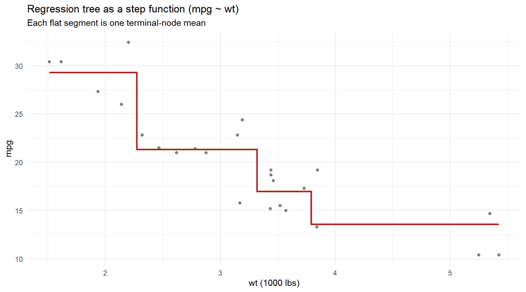

```r
mt_tree_wt <- tree(mpg ~ wt, data = mt_train)

wt_grid <- tibble(
  wt = seq(min(mt_train$wt), max(mt_train$wt), length.out = 300)
) %>%
  mutate(mpg_hat = predict(mt_tree_wt, newdata = .))

ggplot(mt_train, aes(x = wt, y = mpg)) +
  geom_point(color = "grey35", alpha = 0.75) +
  geom_step(
    data = wt_grid,
    aes(x = wt, y = mpg_hat),
    color = "firebrick",
    linewidth = 1
  ) +
  labs(
    title = "Regression tree as a step function (mpg ~ wt)",
    subtitle = "Each flat segment is one terminal-node mean",
    x = "wt (1000 lbs)",
    y = "mpg"
  ) +
  theme_minimal()
```

```r
mt_pred <- predict(mt_tree, newdata = mt_test)

rmse <- sqrt(mean((mt_pred - mt_test$mpg)^2))
cat("Test RMSE:", round(rmse, 3), "\n")
```

```
## Test RMSE: 2.667
```

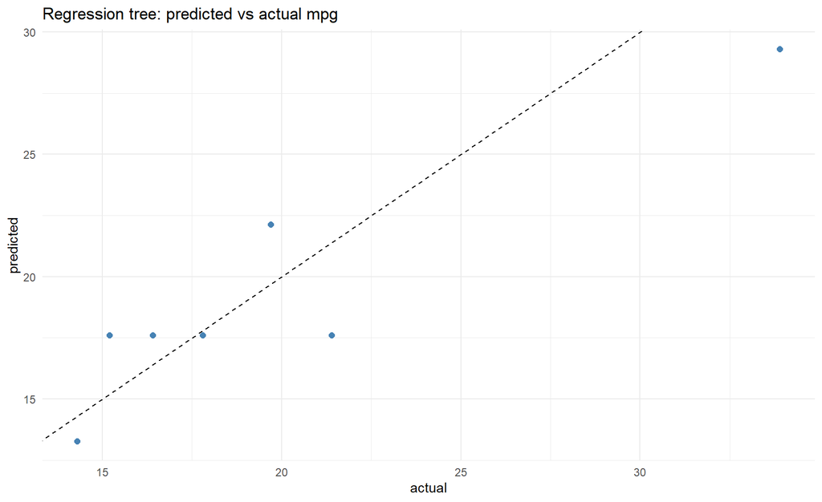

```r
tibble(actual = mt_test$mpg, predicted = mt_pred) %>%
  ggplot(aes(x = actual, y = predicted)) +
  geom_point(size = 2, color = "steelblue") +
  geom_abline(slope = 1, intercept = 0, linetype = "dashed") +
  labs(title = "Regression tree: predicted vs actual mpg") +
  theme_minimal()
```

# 5 Classification Case Study (Heart)

We download the dataset, clean it, and create a stratified train/test split.

```r
url <- "https://www.statlearning.com/s/Heart.csv"
heart_raw <- read.csv(url)

heart_data <- na.omit(heart_raw)

# drop the ID column
heart_data$X <- NULL

# Convert to factors character variables
char_cols <- sapply(heart_data, is.character)
heart_data[char_cols] <- lapply(heart_data[char_cols], factor)

summary(heart_data)
```

```
##       Age             Sex                ChestPain       RestBP
##  Min.   :29.00   Min.   :0.0000   asymptomatic:142   Min.   : 94.0
##  1st Qu.:48.00   1st Qu.:0.0000   nonanginal  : 83   1st Qu.:120.0
##  Median :56.00   Median :1.0000   nontypical  : 49   Median :130.0
##  Mean   :54.54   Mean   :0.6768   typical     : 23   Mean   :131.7
##  3rd Qu.:61.00   3rd Qu.:1.0000                      3rd Qu.:140.0
##  Max.   :77.00   Max.   :1.0000                      Max.   :200.0
##       Chol            Fbs            RestECG           MaxHR
##  Min.   :126.0   Min.   :0.0000   Min.   :0.0000   Min.   : 71.0
##  1st Qu.:211.0   1st Qu.:0.0000   1st Qu.:0.0000   1st Qu.:133.0
##  Median :243.0   Median :0.0000   Median :1.0000   Median :153.0
##  Mean   :247.4   Mean   :0.1448   Mean   :0.9966   Mean   :149.6
##  3rd Qu.:276.0   3rd Qu.:0.0000   3rd Qu.:2.0000   3rd Qu.:166.0
##  Max.   :564.0   Max.   :1.0000   Max.   :2.0000   Max.   :202.0
##      ExAng           Oldpeak          Slope             Ca
##  Min.   :0.0000   Min.   :0.000   Min.   :1.000   Min.   :0.0000
##  1st Qu.:0.0000   1st Qu.:0.000   1st Qu.:1.000   1st Qu.:0.0000
##  Median :0.0000   Median :0.800   Median :2.000   Median :0.0000
##  Mean   :0.3266   Mean   :1.056   Mean   :1.603   Mean   :0.6768
##  3rd Qu.:1.0000   3rd Qu.:1.600   3rd Qu.:2.000   3rd Qu.:1.0000
##  Max.   :1.0000   Max.   :6.200   Max.   :3.000   Max.   :3.0000
##          Thal      AHD
##  fixed     : 18   No :160
##  normal    :164   Yes:137
##  reversable:115
##
##
##
```

```r
set.seed(my_seed)
heart_train_idx <- createDataPartition(heart_data$AHD, p = 0.7, list = FALSE)
train_heart <- heart_data[heart_train_idx, ]
test_heart <- heart_data[-heart_train_idx, ]

cat("Heart train rows:", nrow(train_heart), "\n")
```

```
## Heart train rows: 208
```

```r
cat("Heart test rows:", nrow(test_heart), "\n")
```

```
## Heart test rows: 89
```

We start with a single tree, then prune it via cross-validation, and evaluate on the test set.

```r
cls_tree <- tree(AHD ~ ., data = train_heart)
print(summary(cls_tree))
```

```
##
## Classification tree:
## tree(formula = AHD ~ ., data = train_heart)
## Variables actually used in tree construction:
## [1] "Thal"      "Age"       "MaxHR"     "Sex"       "ChestPain" "Ca"
## [7] "Oldpeak"   "RestBP"    "ExAng"
## Number of terminal nodes:  19
## Residual mean deviance:  0.4506 = 85.17 / 189
## Misclassification error rate: 0.101 = 21 / 208
```

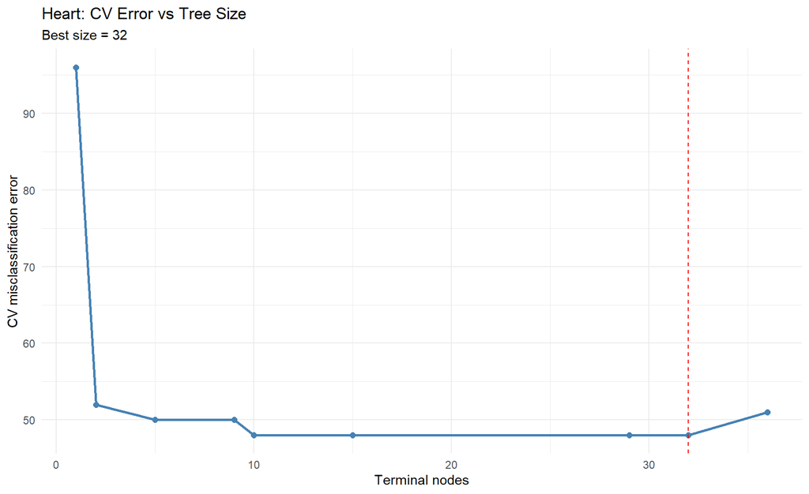

```r
cls_tree_full <- tree(
  AHD ~ ., data = train_heart,
  control = tree.control(nobs = nrow(train_heart), minsize = 2, mindev = 0)
)

set.seed(my_seed)
cv_cls <- cv.tree(cls_tree_full, FUN = prune.misclass)

best_size_cls <- cv_cls$size[which.min(cv_cls$dev)]
cls_tree_pruned <- prune.misclass(cls_tree_full, best = best_size_cls)

cv_cls_df <- tibble(size = cv_cls$size, cv_error = cv_cls$dev)

pruning_plot <- ggplot(cv_cls_df, aes(x = size, y = cv_error)) +
  geom_line(color = "steelblue", linewidth = 1) +
  geom_point(color = "steelblue", size = 2) +
  geom_vline(xintercept = best_size_cls, linetype = "dashed", color = "red") +
  labs(
    title = "Heart: CV Error vs Tree Size",
    subtitle = paste("Best size =", best_size_cls),
    x = "Terminal nodes",
    y = "CV misclassification error"
  ) +
  theme_minimal()

pruning_plot
```

```r
cls_tree_prob <- predict(cls_tree_pruned, newdata = test_heart, type = "vector")
cls_tree_prob_yes <- if ("Yes" %in% colnames(cls_tree_prob)) as.numeric(cls_tree_prob[, "Yes"]) else as.numeric(cls_tree_prob[, 2])
cls_tree_pred <- factor(ifelse(cls_tree_prob_yes >= 0.5, "Yes", "No"), levels = c("No", "Yes"))

metrics_cls_tree <- class_metrics(test_heart$AHD, cls_tree_pred)
metrics_cls_tree
```

```
## # A tibble: 1 × 3
##   Accuracy Sensitivity Specificity
##      <dbl>       <dbl>       <dbl>
## 1    0.775       0.732       0.812
```

Bagging corresponds to a random forest with `mtry = p` (all predictors considered at each split).

```r
p_cls <- ncol(train_heart) - 1

set.seed(my_seed)
bag_cls <- randomForest(
  AHD ~ ., data = train_heart,
  mtry = p_cls,
  ntree = ntree_main,
  importance = TRUE
)

bag_cls_prob <- predict(bag_cls, newdata = test_heart, type = "prob")
bag_cls_prob_yes <- if ("Yes" %in% colnames(bag_cls_prob)) as.numeric(bag_cls_prob[, "Yes"]) else as.numeric(bag_cls_prob[, 2])
bag_cls_pred <- predict(bag_cls, newdata = test_heart, type = "response")

metrics_cls_bag <- class_metrics(test_heart$AHD, bag_cls_pred)
metrics_cls_bag
```

```
## # A tibble: 1 × 3
##   Accuracy Sensitivity Specificity
##      <dbl>       <dbl>       <dbl>
## 1    0.798       0.707       0.875
```

Next we tune `mtry` with OOB error and fit a random forest.

```r
base_mtry_cls <- max(1, floor(sqrt(p_cls)))
mtry_grid_cls <- sort(unique(pmax(1, pmin(p_cls, c(base_mtry_cls - 1, base_mtry_cls, base_mtry_cls + 1, p_cls)))))

rf_cls_tuning <- map_dfr(mtry_grid_cls, function(m) {
  set.seed(my_seed + m)
  fit <- randomForest(AHD ~ ., data = train_heart, mtry = m, ntree = ntree_fast)

  tibble(
    mtry = m,
    OOB_Error = fit$err.rate[ntree_fast, "OOB"]
  )
})

best_mtry_cls <- rf_cls_tuning$mtry[which.min(rf_cls_tuning$OOB_Error)]

set.seed(my_seed)
rf_cls <- randomForest(
  AHD ~ ., data = train_heart,
  mtry = best_mtry_cls,
  ntree = ntree_main,
  importance = TRUE
)

rf_cls_prob <- predict(rf_cls, newdata = test_heart, type = "prob")
rf_cls_prob_yes <- if ("Yes" %in% colnames(rf_cls_prob)) as.numeric(rf_cls_prob[, "Yes"]) else as.numeric(rf_cls_prob[, 2])
rf_cls_pred <- predict(rf_cls, newdata = test_heart, type = "response")

metrics_cls_rf <- class_metrics(test_heart$AHD, rf_cls_pred)
metrics_cls_rf
```

```
## # A tibble: 1 × 3
##   Accuracy Sensitivity Specificity
##      <dbl>       <dbl>       <dbl>
## 1    0.831       0.756       0.896
```

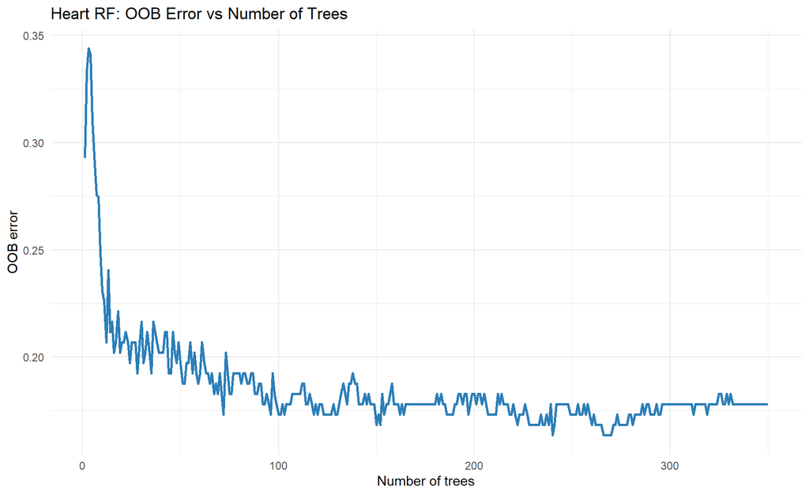

```r
oob_ntree_df <- tibble(
  Trees = seq_len(nrow(rf_cls$err.rate)),
  OOB_Error = rf_cls$err.rate[, "OOB"]
)

p_oob_ntree <- ggplot(oob_ntree_df, aes(x = Trees, y = OOB_Error)) +
  geom_line(color = "#2c7fb8", linewidth = 1) +
  labs(title = "Heart RF: OOB Error vs Number of Trees", x = "Number of trees", y = "OOB error") +
  theme_minimal()

p_oob_mtry <- ggplot(rf_cls_tuning, aes(x = mtry, y = OOB_Error)) +
  geom_line(color = "#41ab5d", linewidth = 1) +
  geom_point(color = "#41ab5d", size = 2.4) +
  geom_vline(xintercept = best_mtry_cls, linetype = "dashed", color = "red") +
  labs(title = "Heart RF: OOB Error vs mtry", x = "mtry", y = "OOB error") +
  theme_minimal()

p_oob_ntree
```

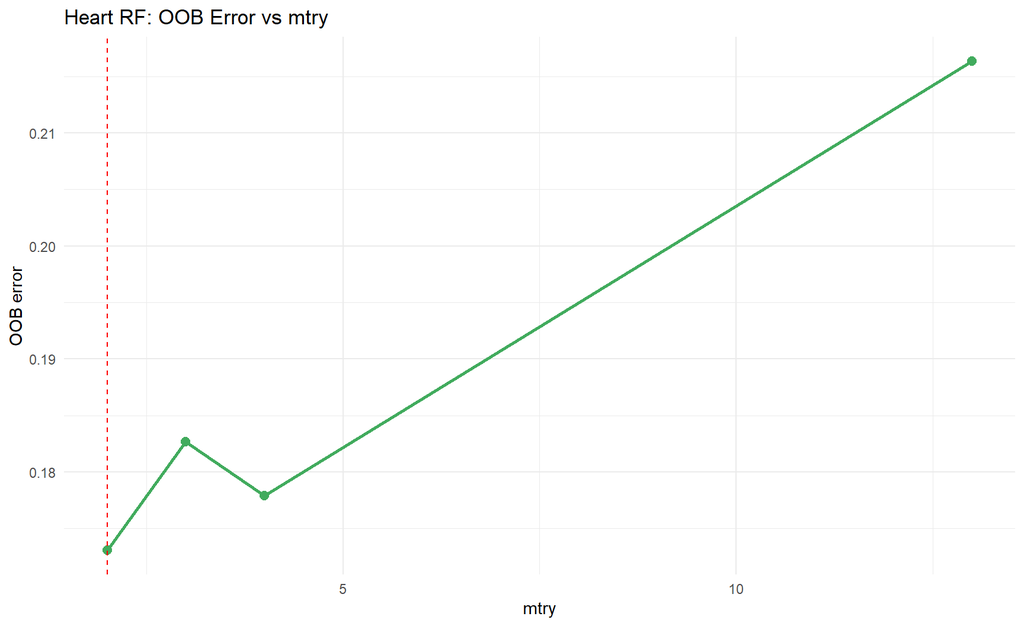

```r
p_oob_mtry
```

We inspect variable importance from the fitted random forest.

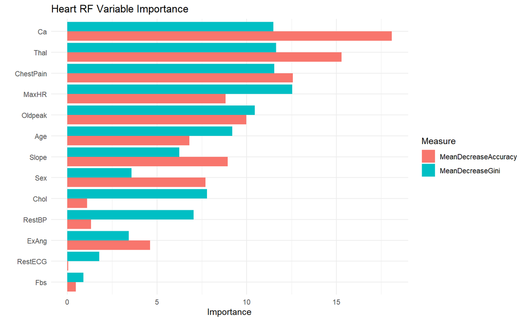

```r
imp_cls <- as.data.frame(importance(rf_cls))
imp_cls$Variable <- rownames(imp_cls)

importance_cols <- intersect(c("MeanDecreaseAccuracy", "MeanDecreaseGini"), names(imp_cls))
imp_cls_long <- imp_cls %>%
  select(Variable, all_of(importance_cols)) %>%
  pivot_longer(cols = -Variable, names_to = "Measure", values_to = "Importance")

ggplot(imp_cls_long, aes(x = fct_reorder(Variable, Importance), y = Importance, fill = Measure)) +
  geom_col(position = "dodge") +
  coord_flip() +
  labs(title = "Heart RF Variable Importance", x = "", y = "Importance") +
  theme_minimal()
```

We fit a compact GBM grid using `caret`.

```r
cls_ctrl <- trainControl(
  method = "cv",
  number = cv_folds,
  classProbs = TRUE,
  summaryFunction = twoClassSummary
)

cls_grid <- expand.grid(
  interaction.depth = c(1, 2),
  n.trees = c(100, 250),
  shrinkage = c(0.05, 0.1),
  n.minobsinnode = c(10)
)

set.seed(my_seed)
gbm_cls <- train(
  AHD ~ ., data = train_heart,
  method = "gbm",
  trControl = cls_ctrl,
  tuneGrid = cls_grid,
  metric = "ROC",
  verbose = FALSE
)

gbm_cls_prob <- predict(gbm_cls, newdata = test_heart, type = "prob")
gbm_cls_prob_yes <- if ("Yes" %in% colnames(gbm_cls_prob)) as.numeric(gbm_cls_prob[, "Yes"]) else as.numeric(gbm_cls_prob[, 2])
gbm_cls_pred <- factor(ifelse(gbm_cls_prob_yes >= 0.5, "Yes", "No"), levels = c("No", "Yes"))

metrics_cls_gbm <- class_metrics(test_heart$AHD, gbm_cls_pred)
metrics_cls_gbm
```

```
## # A tibble: 1 × 3
##   Accuracy Sensitivity Specificity
##      <dbl>       <dbl>       <dbl>
## 1    0.843       0.805       0.875
```

We also fit an XGBoost model to compare directly with GBM.

```r
xgb_terms_cls <- terms(AHD ~ ., data = train_heart)
x_train_xgb_cls <- model.matrix(xgb_terms_cls, data = train_heart)[, -1]
x_test_xgb_cls <- model.matrix(xgb_terms_cls, data = test_heart)[, -1]
y_train_xgb_cls <- as.numeric(train_heart$AHD == "Yes")

set.seed(my_seed + 10)
xgb_dtrain_cls <- xgb.DMatrix(data = x_train_xgb_cls, label = y_train_xgb_cls)
xgb_dtest_cls <- xgb.DMatrix(data = x_test_xgb_cls)

xgb_cls <- xgb.train(
  params = list(
    objective = "binary:logistic",
    eval_metric = "auc",
    eta = 0.05,
    max_depth = 3,
    subsample = 0.8,
    colsample_bytree = 0.8,
    min_child_weight = 1,
    gamma = 0
  ),
  data = xgb_dtrain_cls,
  nrounds = 250,
  verbose = 0
)

xgb_cls_prob_yes <- as.numeric(predict(xgb_cls, newdata = xgb_dtest_cls))
xgb_cls_pred <- factor(ifelse(xgb_cls_prob_yes >= 0.5, "Yes", "No"), levels = c("No", "Yes"))

metrics_cls_xgb <- class_metrics(test_heart$AHD, xgb_cls_pred)
metrics_cls_xgb
```

```
## # A tibble: 1 × 3
##   Accuracy Sensitivity Specificity
##      <dbl>       <dbl>       <dbl>
## 1    0.798       0.732       0.854
```

We collect the classification metrics in a single comparison table.

```r
classification_results <- bind_rows(
  metrics_cls_tree %>% mutate(Method = "Tree (Pruned)"),
  metrics_cls_bag %>% mutate(Method = "Bagging"),
  metrics_cls_rf %>% mutate(Method = "Random Forest"),
  metrics_cls_gbm %>% mutate(Method = "GBM"),
  metrics_cls_xgb %>% mutate(Method = "XGBoost")
) %>%
  select(Method, Accuracy, Sensitivity, Specificity, everything())

knitr::kable(classification_results, digits = 3, caption = "Classification results on Heart test set")
```

Classification results on Heart test set

| Method | Accuracy | Sensitivity | Specificity |
| --- | --- | --- | --- |
| Tree (Pruned) | 0.775 | 0.732 | 0.812 |
| Bagging | 0.798 | 0.707 | 0.875 |
| Random Forest | 0.831 | 0.756 | 0.896 |
| GBM | 0.843 | 0.805 | 0.875 |
| XGBoost | 0.798 | 0.732 | 0.854 |

# 6 Regression Case Study (Boston Housing)

This section applies the same regression toolbox to a larger benchmark dataset (`Boston`, 506 rows) to see how methods scale beyond the previous examples.

We start by loading the dataset and creating a train/test split.

```r
boston_data <- MASS::Boston %>%
  mutate(chas = factor(chas))

summary(boston_data)
```

```
##       crim                zn             indus       chas         nox
##  Min.   : 0.00632   Min.   :  0.00   Min.   : 0.46   0:471   Min.   :0.3850
##  1st Qu.: 0.08205   1st Qu.:  0.00   1st Qu.: 5.19   1: 35   1st Qu.:0.4490
##  Median : 0.25651   Median :  0.00   Median : 9.69           Median :0.5380
##  Mean   : 3.61352   Mean   : 11.36   Mean   :11.14           Mean   :0.5547
##  3rd Qu.: 3.67708   3rd Qu.: 12.50   3rd Qu.:18.10           3rd Qu.:0.6240
##  Max.   :88.97620   Max.   :100.00   Max.   :27.74           Max.   :0.8710
##        rm             age              dis              rad
##  Min.   :3.561   Min.   :  2.90   Min.   : 1.130   Min.   : 1.000
##  1st Qu.:5.886   1st Qu.: 45.02   1st Qu.: 2.100   1st Qu.: 4.000
##  Median :6.208   Median : 77.50   Median : 3.207   Median : 5.000
##  Mean   :6.285   Mean   : 68.57   Mean   : 3.795   Mean   : 9.549
##  3rd Qu.:6.623   3rd Qu.: 94.08   3rd Qu.: 5.188   3rd Qu.:24.000
##  Max.   :8.780   Max.   :100.00   Max.   :12.127   Max.   :24.000
##       tax           ptratio          black            lstat
##  Min.   :187.0   Min.   :12.60   Min.   :  0.32   Min.   : 1.73
##  1st Qu.:279.0   1st Qu.:17.40   1st Qu.:375.38   1st Qu.: 6.95
##  Median :330.0   Median :19.05   Median :391.44   Median :11.36
##  Mean   :408.2   Mean   :18.46   Mean   :356.67   Mean   :12.65
##  3rd Qu.:666.0   3rd Qu.:20.20   3rd Qu.:396.23   3rd Qu.:16.95
##  Max.   :711.0   Max.   :22.00   Max.   :396.90   Max.   :37.97
##       medv
##  Min.   : 5.00
##  1st Qu.:17.02
##  Median :21.20
##  Mean   :22.53
##  3rd Qu.:25.00
##  Max.   :50.00
```

```r
set.seed(my_seed + 200)
boston_train_idx <- createDataPartition(boston_data$medv, p = 0.75, list = FALSE)
train_boston <- boston_data[boston_train_idx, ]
test_boston <- boston_data[-boston_train_idx, ]

cat("Boston rows:", nrow(boston_data), "\n")
```

```
## Boston rows: 506
```

```r
cat("Boston train rows:", nrow(train_boston), "\n")
```

```
## Boston train rows: 381
```

```r
cat("Boston test rows:", nrow(test_boston), "\n")
```

```
## Boston test rows: 125
```

We fit a single regression tree and prune it.

```r
boston_tree_full <- tree(
  medv ~ ., data = train_boston,
  control = tree.control(nobs = nrow(train_boston), minsize = 5, mindev = 0)
)

set.seed(my_seed + 201)
cv_boston <- cv.tree(boston_tree_full)
best_size_boston <- cv_boston$size[which.min(cv_boston$dev)]
boston_tree_pruned <- prune.tree(boston_tree_full, best = best_size_boston)

boston_tree_pred <- predict(boston_tree_pruned, newdata = test_boston)
metrics_boston_tree <- reg_metrics(test_boston$medv, boston_tree_pred)
metrics_boston_tree
```

```
## # A tibble: 1 × 3
##    RMSE   MAE    R2
##   <dbl> <dbl> <dbl>
## 1  3.76  2.78 0.828
```

We then fit bagging (random forest with `mtry = p`).

```r
p_boston <- ncol(train_boston) - 1

set.seed(my_seed + 202)
bag_boston <- randomForest(
  medv ~ ., data = train_boston,
  mtry = p_boston,
  ntree = ntree_main,
  importance = TRUE
)

bag_boston_pred <- predict(bag_boston, newdata = test_boston)
metrics_boston_bag <- reg_metrics(test_boston$medv, bag_boston_pred)
metrics_boston_bag
```

```
## # A tibble: 1 × 3
##    RMSE   MAE    R2
##   <dbl> <dbl> <dbl>
## 1  2.60  1.91 0.918
```

We tune `mtry` with OOB MSE and fit a random forest.

```r
base_mtry_boston <- max(1, floor(p_boston / 3))
mtry_grid_boston <- sort(unique(pmax(1, pmin(p_boston, c(base_mtry_boston - 1, base_mtry_boston, base_mtry_boston + 1, p_boston)))))

rf_boston_tuning <- map_dfr(mtry_grid_boston, function(m) {
  set.seed(my_seed + 220 + m)
  fit <- randomForest(medv ~ ., data = train_boston, mtry = m, ntree = ntree_fast)

  tibble(
    mtry = m,
    OOB_MSE = fit$mse[ntree_fast]
  )
})

best_mtry_boston <- rf_boston_tuning$mtry[which.min(rf_boston_tuning$OOB_MSE)]

set.seed(my_seed + 203)
rf_boston <- randomForest(
  medv ~ ., data = train_boston,
  mtry = best_mtry_boston,
  ntree = ntree_main,
  importance = TRUE
)

rf_boston_pred <- predict(rf_boston, newdata = test_boston)
metrics_boston_rf <- reg_metrics(test_boston$medv, rf_boston_pred)
metrics_boston_rf
```

```
## # A tibble: 1 × 3
##    RMSE   MAE    R2
##   <dbl> <dbl> <dbl>
## 1  2.97  1.92 0.893
```

We fit a compact GBM grid.

```r
boston_ctrl <- trainControl(method = "cv", number = cv_folds)

boston_grid <- expand.grid(
  interaction.depth = c(1, 2, 3),
  n.trees = c(100, 250),
  shrinkage = c(0.05, 0.1),
  n.minobsinnode = c(10)
)

set.seed(my_seed + 204)
gbm_boston <- train(
  medv ~ ., data = train_boston,
  method = "gbm",
  trControl = boston_ctrl,
  tuneGrid = boston_grid,
  metric = "RMSE",
  verbose = FALSE
)

gbm_boston_pred <- predict(gbm_boston, newdata = test_boston)
metrics_boston_gbm <- reg_metrics(test_boston$medv, gbm_boston_pred)
metrics_boston_gbm
```

```
## # A tibble: 1 × 3
##    RMSE   MAE    R2
##   <dbl> <dbl> <dbl>
## 1  2.86  1.99 0.900
```

We also fit XGBoost for Boston to compare with GBM on the same split.

```r
xgb_terms_boston <- terms(medv ~ ., data = train_boston)
x_train_xgb_boston <- model.matrix(xgb_terms_boston, data = train_boston)[, -1]
x_test_xgb_boston <- model.matrix(xgb_terms_boston, data = test_boston)[, -1]
y_train_xgb_boston <- train_boston$medv

set.seed(my_seed + 210)
xgb_boston <- xgboost(
  data = x_train_xgb_boston,
  label = y_train_xgb_boston,
  objective = "reg:squarederror",
  eval_metric = "rmse",
  nrounds = 300,
  eta = 0.05,
  max_depth = 3,
  subsample = 0.8,
  colsample_bytree = 0.8,
  min_child_weight = 1,
  gamma = 0,
  verbose = 0
)

xgb_boston_pred <- as.numeric(predict(xgb_boston, newdata = x_test_xgb_boston))
metrics_boston_xgb <- reg_metrics(test_boston$medv, xgb_boston_pred)
metrics_boston_xgb
```

```
## # A tibble: 1 × 3
##    RMSE   MAE    R2
##   <dbl> <dbl> <dbl>
## 1  2.45  1.89 0.927
```

We collect results in a comparison table and visualise RMSE.

```r
boston_results <- bind_rows(
  metrics_boston_tree %>% mutate(Method = "Tree (Pruned)"),
  metrics_boston_bag %>% mutate(Method = "Bagging"),
  metrics_boston_rf %>% mutate(Method = "Random Forest"),
  metrics_boston_gbm %>% mutate(Method = "GBM"),
  metrics_boston_xgb %>% mutate(Method = "XGBoost")
) %>%
  select(Method, RMSE, MAE, R2, everything()) %>%
  arrange(RMSE)

knitr::kable(boston_results, digits = 3, caption = "Boston housing: regression method comparison on test set")
```

Boston housing: regression method comparison on test set

| Method | RMSE | MAE | R2 |
| --- | --- | --- | --- |
| XGBoost | 2.450 | 1.894 | 0.927 |
| Bagging | 2.596 | 1.911 | 0.918 |
| GBM | 2.862 | 1.990 | 0.900 |
| Random Forest | 2.967 | 1.924 | 0.893 |
| Tree (Pruned) | 3.756 | 2.777 | 0.828 |

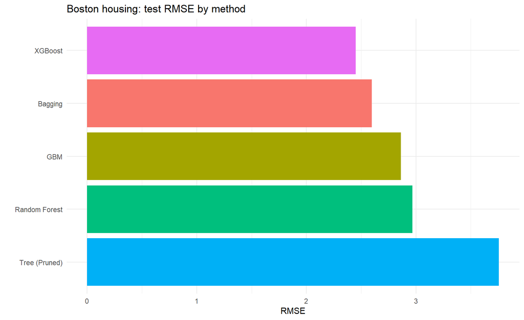

```r
ggplot(boston_results, aes(x = fct_reorder(Method, -RMSE), y = RMSE, fill = Method)) +
  geom_col(show.legend = FALSE) +
  coord_flip() +
  labs(
    title = "Boston housing: test RMSE by method",
    x = "",
    y = "RMSE"
  ) +
  theme_minimal()
```

# 7 Some R packages for tree-based models

- **`tree`**: lightweight package for classification and regression trees with cross-validation pruning.
- **`rpart`** + **`rpart.plot`**: more feature-rich alternative for decision trees with nicer visualisation.
- **`randomForest`**: the classic implementation of bagging and random forests.
- **`ranger`**: faster, parallelised random forest with the same interface as `randomForest`.
- **`xgboost`** / **`lightgbm`**: gradient boosting specific methods
- **`caret`** / **`tidymodels`**: unified interfaces that wrap all the above for cross-validation, hyperparameter tuning, and pipelines.